# Longitudinal Modeling of Cognitive Decline in Older Adults Using GLM, GEE, and GLMM: An Analysis of the OASIS-2 Cohort

Author

Yini Lu, Wan-Chen Lin, Rui Peng, Yixin Zhang

## 1 Introduction

Alzheimer’s disease (AD) is the most common cause of dementia worldwide and remains one of the most pressing public health challenges of the 21st century. Global estimates consistently show that the number of individuals with dementia will rise substantially as populations age, placing increasing demands on health systems, caregivers, and societies. International reports by Alzheimer’s Disease International and the World Health Organization highlight the accelerating global burden of dementia and emphasize the importance of early identification and intervention ([1], [2]). Additional epidemiological analyses further demonstrate sharp projected increases in dementia prevalence across diverse regions, with recent summaries underscoring the significant clinical and economic implications of this trend ([3], [4]).

Accurate and early cognitive assessment plays a central role in diagnosing Alzheimer’s disease, evaluating disease progression, and identifying individuals at elevated risk of cognitive decline. The Mini-Mental State Examination (MMSE) is one of the most widely used tools for assessing global cognitive status in both clinical practice and research. Originally developed as a brief, standardized screening test for cognitive impairment [5], the MMSE has been extensively validated in psychometric and methodological reviews [6]. A comprehensive Cochrane review confirms its practical diagnostic accuracy in community and primary care settings, particularly among older adults without prior cognitive evaluation [7]. Its short administration time, standardized scoring, and widespread clinical familiarity have established the MMSE as a central component of AD assessment frameworks.

A critical aspect of using the MMSE in both clinical and epidemiologic research is identifying a meaningful cutoff for cognitive impairment. A well-established threshold is a total score below 24, which corresponds to at least mild impairment and indicates elevated risk for functional decline. Validation studies show that **MMSE < 24** demonstrates high specificity for probable Alzheimer’s disease, even across diverse demographic groups. In highly educated samples, the standard cutoff retains excellent specificity and acceptable sensitivity [8]. Although more recent calibration studies have proposed refined thresholds for distinguishing different impairment levels, **MMSE < 24 remains a widely used and clinically intuitive definition of poor cognition [9]**. At the same time, population-based norms reveal that MMSE performance varies systematically by age and education, highlighting the need to adjust for demographic covariates when evaluating cognitive status or decline [10].

Understanding cognitive decline requires longitudinal assessment. A growing body of evidence links demographic characteristics to differences in cognitive functioning and trajectories. Education is strongly associated with baseline cognitive performance, often interpreted through cognitive reserve theory; however, research suggests that education primarily influences initial cognitive level rather than the rate of decline [11]. Sex-specific patterns have also been documented, with educational gradients in cognitive impairment risk varying by gender and age [12]. Additionally, life-course factors, including parental education, contribute to later-life cognitive functioning [13]. These findings underscore the importance of modeling demographic and clinical influences, including age, sex, and education, when examining cognitive outcomes.

Given this context, the present study investigates two key research questions: (a) How does education level influence poor cognition (MMSE < 24), adjusting for age and sex? and (b) How does education level influence the continuous MMSE score over time, adjusting for age and sex? By modeling cognitive impairment as a dynamic process and examining how demographic and clinical factors shape both the likelihood and progression of poor cognition, this study aims to clarify the determinants of cognitive decline and inform strategies for early risk identification and dementia-focused interventions.

To address these research aims, we utilize data from the Open Access Series of Imaging Studies (`OASIS`), a publicly available neuroimaging dataset designed to support research on brain aging and Alzheimer’s disease. The longitudinal structure of the `OASIS` dataset provides a unique opportunity to examine cognitive trajectories across a wide age range and across dementia statuses. This enables our study to investigate how baseline demographic and clinical factors, including age, sex, education, relate to both the probability and progression of poor cognition as reflected in longitudinal MMSE performance.

Methodologically, we employ three complementary modeling approaches to address our two research questions: a generalized linear model (GLM) to estimate baseline associations with the probability of poor cognition (`MMSE < 24`) and the change of MMSE ($\Delta MMSE$ ), and both generalized linear mixed models (GLMM) and generalized estimating equations (GEE) to analyze longitudinal changes in MMSE outcomes and the evolution of poor-cognition risk over time.

## 2 Methods

### 2.1 Dataset description

`OASIS` provides richly detailed cross-sectional and longitudinal magnetic resonance imaging (MRI) data collected through collaborations among the Washington University Alzheimer’s Disease Research Center, the Neuroinformatics Research Group at Washington University, the Biomedical Informatics Research Network, and the Howard Hughes Medical Institute. The longitudinal dataset includes 142 adults aged 60 to 96, each with two or more MRI sessions separated by at least one year, totaling 373 imaging sessions. Within this cohort, 72 participants were nondemented across all visits, 56 were demented at baseline , and 14 transitioned from nondemented to demented during follow-up.

Table 1: Baseline Descriptive Statistics

Descriptive statistics by education level (Low / Medium / High)

| Variable | Overall | Low | Medium | High |
| --- | --- | --- | --- | --- |
| N | 142 | 46 | 30 | 66 |
| age | 75.44 (7.72) | 76.24 (7.44) | 75.87 (8.65) | 74.68 (7.52) |
| mmse | 27.63 (2.99) | 26.83 (3.52) | 27.37 (3.09) | 28.30 (2.37) |
| sex = F | 84 (59.2%) | 27 (58.7%) | 21 (70.0%) | 36 (54.5%) |
| sex = M | 58 (40.8%) | 19 (41.3%) | 9 (30.0%) | 30 (45.5%) |

At baseline (visit = 1), the OASIS dataset included 142 participants across three groups (`High Education`, `Medium Education` and `Low Education`). Descriptive statistics for age, education, MMSE, and sex distribution at baseline are summarized in Table 1 .

#### 2.1.1 Research Problem 1

We defined `poor cognition`as `MMSE < 24` at the final observed visit, a commonly used threshold for cognitive impairment.

$$Y_i=\mathbb{I}(MMSE_{i,\text{final}}<24)$$

The binary outcome (poor vs. non-poor cognition, based on MMSE) was modeled using three complementary approaches:

- **Logistic generalized linear model (GLM)**
  - Cross-sectional analysis using baseline predictors to estimate the odds of poor cognition at the final assessment.
- **Logistic generalized estimating equations (GEE)**
  - Population-averaged model for repeated MMSE-based outcomes, accounting for within-subject correlation across visits.
- **Logistic generalized linear mixed model (GLMM)**
  - Subject-specific model with random effects, providing individual-level trajectories of the probability of poor cognition over time.

#### 2.1.2 Research Problem 2

The methods we used for this problem are:

- GLM (linear): overall change from baseline to last visit ($\Delta MMSE$)
- GEE (Gaussian, identity link): population-average MMSE trajectory over time
- GLMM (linear mixed model): subject-specific MMSE trajectories over time with random intercepts and slopes

We defined `Change in MMSE` as our final outcome in `GLM` Model. For `GEE` and `GLMM` model, we decided to use `Raw MMSE Score` as our final outcome.

### 2.2 Data Preprocessing

All analyses were conducted using a cleaned version of the OASIS-2 dataset. Participants missing baseline MMSE values were excluded to ensure consistent cognitive assessment across models. For the GLM analyses, we further restricted the sample to individuals with at least two clinical visits so that baseline-to-final change could be defined. Poor cognition was operationalized as `MMSE < 24` at the last available visit for each subject. Continuous predictors (`age`) were inspected for missingness and extreme values, and factor variables (`sex` and `education` group) were cleaned and converted into categorical formats. The design matrix was evaluated for multicollinearity using variance inflation factors (VIF), and no meaningful collinearity was detected. No imputation was performed, and all models were fit using complete-case data. Importantly, the same preprocessed dataset was used to construct outcomes for GLM, GEE, and GLMM, allowing for consistent comparison across cross-sectional, marginal, and subject-specific modeling frameworks.

### 2.3 Methods Description

#### 2.3.1 Generalized Linear Model (GLM)

A cross-sectional logistic generalized linear model (GLM) was used to estimate the association between baseline predictors and the probability of poor cognition at the final assessment (MMSE < 24). The logistic GLM is **well-suited** for this **binary outcome** because it models the log-odds of impairment as a linear function of predictors, provides interpretable effect estimates in the form of odds ratios, and ensures that predicted probabilities remain between 0 and 1. This model summarizes how demographic and clinical characteristics at baseline, specifically age, education, sex, contribute to the probability of cognitive impairment in a single time point analysis. The GLM also serves as a foundational model that establishes baseline association patterns before incorporating longitudinal dependence in repeated-measures frameworks such as GEE and GLMM, offering a computationally efficient and statistically robust first step for identifying key predictors of poor cognition.

The model takes the following form:

$$\text{logit}\left[ P(Y_i = 1) \right]
= \beta_0
+ \beta_1 \text{Age}_i
+ \beta_2 \text{Educ}_i
+ \beta_3 \text{Sex}_i .$$

The following assumptions and diagnostic checks were performed to evaluate the adequacy of the logistic GLM:

- **Correct link function**  
  Verified by assessing whether the logit link appropriately captured the relationship between predictors and the outcome.
- **Independence of observations**  
  Reasonable in this cross-sectional setting, with one observation per participant.
- **Absence of influential outliers**  
  Examined through standardized residuals, leverage values, and Cook’s distance.
- **Multicollinearity**  
  Assessed using variance inflation factors (VIF) for all covariates.
- **Goodness of fit**  
  Evaluated using the Hosmer–Lemeshow test and associated calibration diagnostics.
- **Model discrimination**  
  Quantified using receiver operating characteristic (ROC) curves and the area under the curve (AUC).
- **Calibration**  
  Evaluated by comparing predicted probabilities with observed event rates across decile-based prediction bins.

#### 2.3.2 GEE

##### 2.3.2.1 Model Specification

In our initial GLM analyses we used a main-effects model to describe the association between cognition and baseline covariates, treating observations as independent. When moving to the GEE framework, our scientific question shifted to population-average trajectories of cognition over repeated visits. Exploratory plots of MMSE by education level suggested that the mean profiles over visit were not parallel across education groups, indicating possible effect modification of time by education. To capture these differing slopes, we expanded the GEE mean model to include a visit × education interaction, while retaining the same core covariates (age, sex, and education). Thus, the GEE mean model is an extension of the GLM that allows the effect of time to vary by education level, which is only identifiable in the longitudinal setting.

We analyzed repeated Mini-Mental State Examination (MMSE) measurements across multiple study visits. Education was categorized as Low ($\leq 12$ years), Medium ($13-15$ years), and High ($\geq 16$ years). Sex and baseline age were included as adjustment covariates. Two research questions were addressed:

- RQ1: How does education level influence poor cognition (`MMSE < 24`), adjusting for age and sex?
- RQ2: How does education level influence the continuous MMSE score over time, adjusting for age and sex?

For RQ1, we fit a population-averaged logistic GEE with a binomial family and logit link:

$$\text{logit}\bigl[P(Y_{it} = 1)\bigr]
= \beta_0 + \beta_1 \text{Visit}_{it} + \beta_2 \text{Educ}_i
+ \beta_3 (\text{Visit}_{it} \times \text{Educ}_i)
+ \beta_4 \text{Age}_i + \beta_5 \text{Sex}_i .$$

For RQ2, we modeled MMSE score as a continuous outcome using Gaussian GEE with an identity link:

$$E(\text{MMSE}_{it})
= \beta_0
+ \beta_1 \text{Visit}_{it}
+ \beta_2 \text{Educ}_i
+ \beta_3 (\text{Visit}_{it} \times \text{Educ}_i)
+ \beta_4 \text{Age}_i
+ \beta_5 \text{Sex}_i .$$

##### 2.3.2.2 Choosing the Woking Correlation Structure

We then compared Independence, Exchangeable, and AR-1 structures using the Quasi-likelihood Information Criterion (QIC):

Table 2: QIC Comparison of Correlation Structures For RQ1

| corstr | QIC |
| --- | --- |
| independence | 286.4093 |
| exchangeable | 284.2752 |
| ar1 | 285.9513 |

Table 3: QIC Comparison of Correlation Structures For RQ2

| corstr | QIC |
| --- | --- |
| independence | 4532.336 |
| exchangeable | 4639.781 |
| ar1 | 9530.177 |

#### 2.3.3 GLMM

To address the research questions regarding the relationship between Education and Cognitive Function over time, we fit two mixed-effects models. Both models adjusted for Baseline Age (scaled) and Sex, and included random intercepts to account for within-subject correlation.

For RQ1 (Binary Outcome: Poor Cognition), a logistic Generalized Linear Mixed Model (GLMM) was fit. The model specification included interaction terms between Visit and Education Level to test if the probability of poor cognition changes differently over time based on education:

$$\begin{aligned} \text{logit}(P(Y_{ij}=1)) = & \beta_0 + \beta_1 \text{Visit}_{ij} + \beta_2 \text{Educ}_{\text{Med}} + \beta_3 \text{Educ}_{\text{High}} + \\ & \beta_4 (\text{Visit} \times \text{Educ}_{\text{Med}}) + \beta_5 (\text{Visit} \times \text{Educ}_{\text{High}}) + \\ & \beta_6 \text{Age}_i + \beta_7 \text{Sex}_i + b_{0i} \end{aligned}$$

where $b_{0i} \sim N(0, \sigma_b^2)$.

For RQ2 (Continuous Outcome: MMSE Score), a Linear Mixed Model (LMM) was fit to examine trajectories of cognitive decline. Similar to RQ1, this model included interactions between Visit and Education:

$$\begin{aligned} \text{MMSE}_{ij} = & \beta_0 + \beta_1 \text{Visit}_{ij} + \beta_2 \text{Educ}_{\text{Med}} + \beta_3 \text{Educ}_{\text{High}} + \\ & \beta_4 (\text{Visit} \times \text{Educ}_{\text{Med}}) + \beta_5 (\text{Visit} \times \text{Educ}_{\text{High}}) + \\ & \beta_6 \text{Age}_i + \beta_7 \text{Sex}_i + b_{0i} + \epsilon_{ij} \end{aligned}$$

where the random effects $(b_{0i}, b_{1i})$ are assumed to be normally distributed.

Random effects:

- Random intercept (binary outcome)
- Random intercept + slope (continuous outcome)

Variance components were extracted, and intraclass correlation (ICC) was computed. The Zeger attenuation formula was used to compare conditional and marginal effects.

## 3 Results

### 3.1 Generalized Linear Model (GLM)

#### 3.1.1 Research Question 1 (Binary Outcome):Poor Cognition Probability

##### 3.1.1.1 Model Summary

Table 4: Point-biserial correlation between MMSE and CDR Score

| estimate | statistic | p.value | conf.low | conf.high | method |
| --- | --- | --- | --- | --- | --- |
| -0.6997524 | -11.5898 | <1e-07 | -0.7751316 | -0.6047315 | Pearson’s product-moment correlation |

Table 5: Point-biserial correlation between MMSE and Demented Status

| estimate | statistic | p.value | conf.low | conf.high | method |
| --- | --- | --- | --- | --- | --- |
| -0.6628859 | -10.4757 | <1e-07 | -0.7461383 | -0.5592232 | Pearson’s product-moment correlation |

Before constructing the final model, we first investigated the correlation between our outcome (MMSE score) and potential predictors. Clinical Dementia Rating (CDR) score and dementia status were both strongly correlated with MMSE in our data (see Table 4, Table 5), and previous work has shown that MMSE, CDR, and clinical dementia diagnosis largely reflect overlapping constructs of global cognitive impairment. Consequently, including CDR or dementia status as predictors of MMSE would be conceptually redundant and introduce circularity, so these variables were not considered as candidate predictors in the multivariable models.

Table 6: GLM Model Summary

| term | estimate | std.error | statistic | p.value |
| --- | --- | --- | --- | --- |
| (Intercept) | 2.469 | 2.816 | 0.877 | 0.381 |
| age_baseline | -0.003 | 0.031 | -0.106 | 0.916 |
| educ_baseline | -0.292 | 0.091 | -3.213 | 0.001 |
| sex_baselineM | 0.579 | 0.476 | 1.218 | 0.223 |

Table 7: Odds Ratio table of GLM model

| Predictor | Odds Ratio (95% CI) |
| --- | --- |
| (Intercept) | 11.815 (0.050, 3382.422) |
| age_baseline | 0.997 (0.936, 1.060) |
| educ_baseline | 0.747 (0.617, 0.884) |
| sex_baselineM | 1.784 (0.700, 4.597) |

Moreover, we also summarized the odds ratios (ORs) and 95% confidence intervals (CIs) from the logistic GLM (See Table 7), which modeled the association between baseline predictors and the likelihood of poor cognition at the subject’s final visit. Each additional year of education reduced the odds of poor cognition by approximately $25\%,$ $(OR = 0.75; 95\% CI: 0.62–0.89)$. Baseline age and sex were not significant predictors after adjustment. These results suggest that education is an important protective factor, whereas age and sex alone do not strongly predict poor cognitive outcome when restricted to final-visit data.

##### 3.1.1.2 Model Performance

To evaluate overall model performance, we assessed the classification accuracy by comparing predicted probabilities against the observed outcomes, providing a summary measure of how well the model distinguished individuals with and without poor cognition.

| Metric | Value |
| --- | --- |
| Accuracy | 0.845 |

Table 8: GLM Model Metrics Summary

From Table 8, the model correctly classified most cases ($\approx 85\%$), yielding strong performance for identifying cases.

```
Area under the curve: 0.7143
```

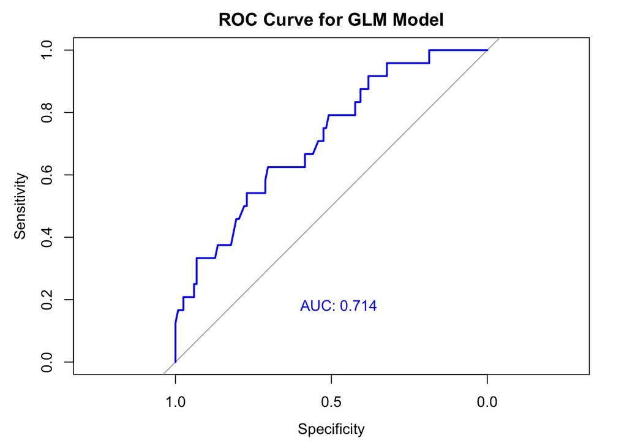

Figure 1: ROC Curve for GLM Model

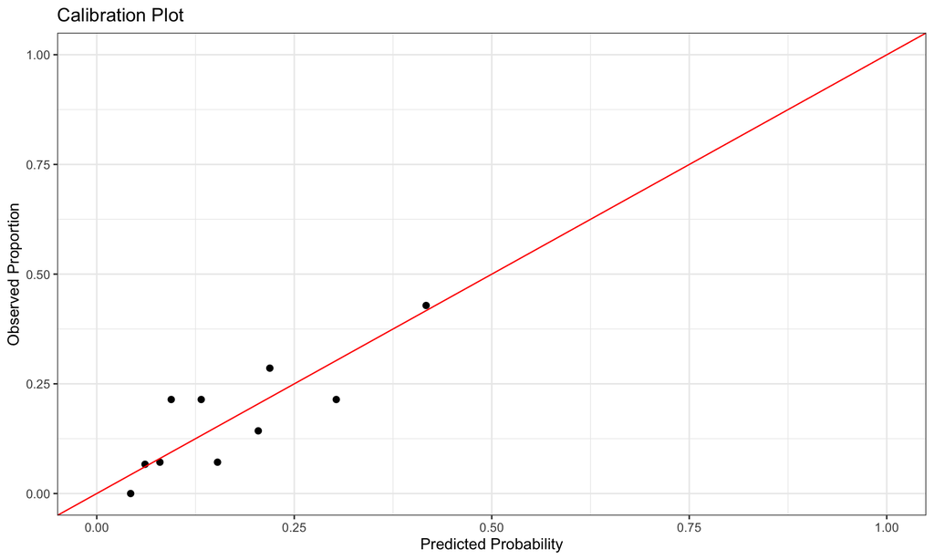

Figure 2: Calibration Plot for GLM

Table 9: Calibration Table (Decile-Based)

| bin | mean_pred | obs_rate |
| --- | --- | --- |
| 1 | 0.043 | 0.000 |
| 2 | 0.061 | 0.067 |
| 3 | 0.080 | 0.071 |
| 4 | 0.094 | 0.214 |
| 5 | 0.132 | 0.214 |
| 6 | 0.153 | 0.071 |
| 7 | 0.204 | 0.143 |
| 8 | 0.219 | 0.286 |
| 9 | 0.303 | 0.214 |
| 10 | 0.417 | 0.429 |

As shown in Table 9 and Figure 2, the calibration plot compares predicted probabilities to observed rates of poor cognition across decile bins. Most points lie close to the 45-degree identity line, suggesting that the logistic GLM provides well-calibrated probability estimates.

Overall, The model is well calibrated for low to moderate risk levels and shows modest underestimation at the highest predicted risks.

##### 3.1.1.3 Model dignostic

###### 3.1.1.3.1 Deviance Residuals

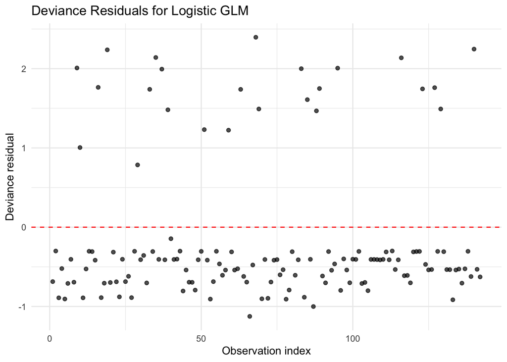

Figure 3: Deivance Residuals Plot for Logistic GLM

From Figure 3, the deviance residual plot shows that most residuals fall within −1 and +1, suggesting that the logistic GLM provides an adequate fit to the majority of individuals. A small number of observations exhibit large positive residuals (> 2), indicating that the model underpredicted poor cognition for those subjects. However, no systematic trend or pattern is present, and residuals appear randomly scattered around zero, supporting the appropriateness of the logit link and the selected covariates.

###### 3.1.1.3.2 Cook’s Distance Plot

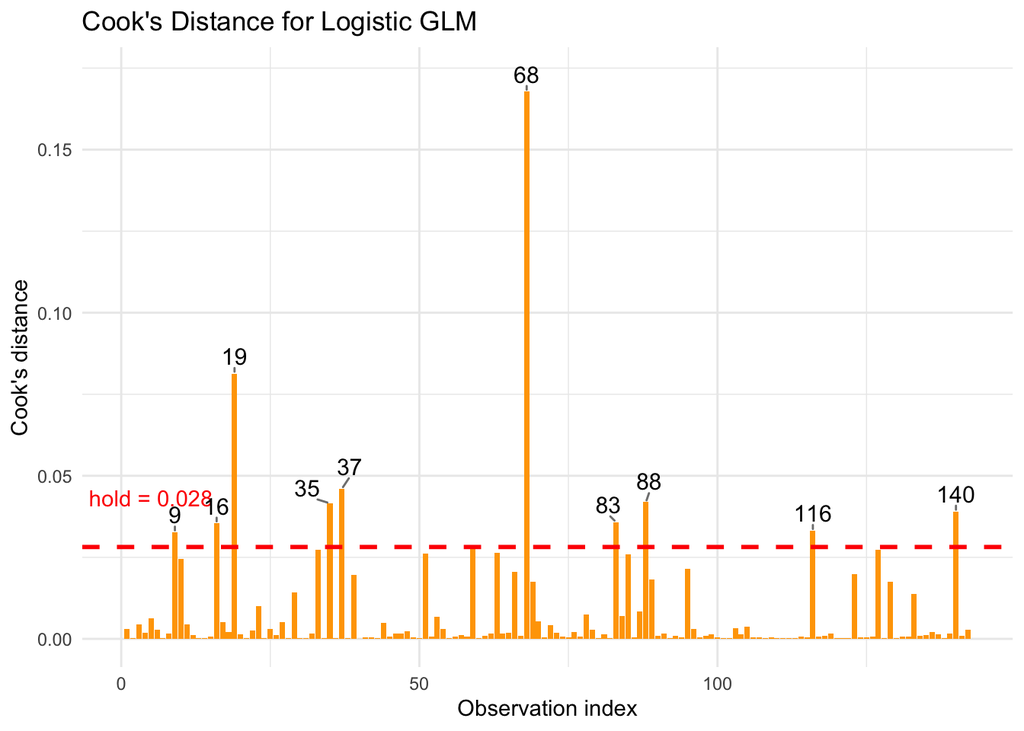

Figure 4: Cook’s Distance Plot for Logistic GLM

###### 3.1.1.3.3 Goodness

| Statistic | Value |
| --- | --- |
| Hosmer–Lemeshow X² | 5.6932 |
| df | 8.0000 |
| p-value | 0.6820 |

Table 10: Hosmer-Lemeshow Goodness-of-Fit Test for Logistics GLM

A Hosmer–Lemeshow goodness-of-fit test was conducted to assess how well the logistic GLM matched the observed data ( Table 10). The test yielded $\chi^2$ = 5.69 with 8 degrees of freedom (p = 0.68>0.05), indicating no evidence of lack of fit. Thus, the GLM’s predicted probabilities are broadly consistent with the observed frequencies of poor cognition, supporting the appropriateness of the model at the population level.

#### 3.1.2 Research Question 2 (Continuous Outcome)-Poor Cognition Probability

##### 3.1.2.1 Model Summary

Table 11: GLM results for RQ2: Predicting change in MMSE from baseline demographics.

| term | estimate | conf.low | conf.high | p.value |
| --- | --- | --- | --- | --- |
| (Intercept) | -8.113 | -14.013 | -2.213 | 0.007 |
| mmse_baseline | 0.142 | -0.001 | 0.284 | 0.051 |
| age_baseline | 0.028 | -0.025 | 0.081 | 0.293 |
| educ_baseline | 0.079 | -0.065 | 0.224 | 0.279 |
| sex_baselineM | 0.308 | -0.541 | 1.157 | 0.475 |

From Table 11, by checking P-value, none of the baseline demographic variables(age, sex, or education) were statistically significant predictors of cognitive change.The estimated change in MMSE from first to last visit is generally a small decline, and this decline appears **similar across age, sex, and education levels**.

##### 3.1.2.2 Model Diagnostics

```
mmse_baseline  age_baseline educ_baseline  sex_baseline
     1.098858      1.006698      1.060388      1.060823
```

Variance inflation factors (VIFs) for all predictors were approximately 1 (VIF $\approx$ 1.01), indicating no evidence of multicollinearity among baseline age, education, and sex. Therefore, all predictors can be interpreted without concern for inflated variances or instability in the coefficient estimates.

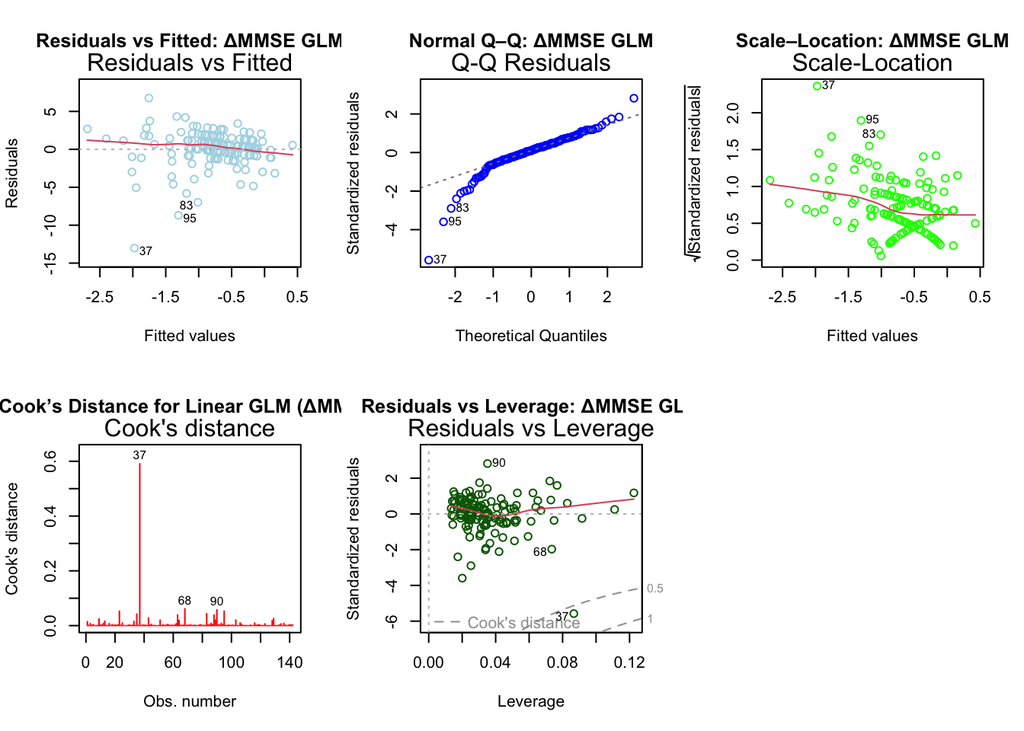

Figure 5: Diagnostic plots for the linear model of ΔMMSE (RQ2).

#### 3.1.3 Conclusion for GLM

In summary,the logistic GLM in Question 1 performs well because the task is cross-sectional and the predictors have a clear and stable relationship with the binary outcome of poor cognition. Since we only need one observation per subject, GLM is appropriate and gives good accuracy, and good calibration.In contrast, the linear GLM in Question 2 is not well-suited for modeling cognitive decline. This model reduces each subject’s entire longitudinal MMSE trajectory to a single difference score.the linear GLM cannot capture how cognition changes over time, because it ignores the repeated-measures .

### 3.2 GEE

#### 3.2.1 Research Question 1 (Bianry Outcome)-Cognitive Decline

##### 3.2.1.1 Visual Exploration

To understand general trends prior to modeling, we visualized individual MMSE trajectories by education category.

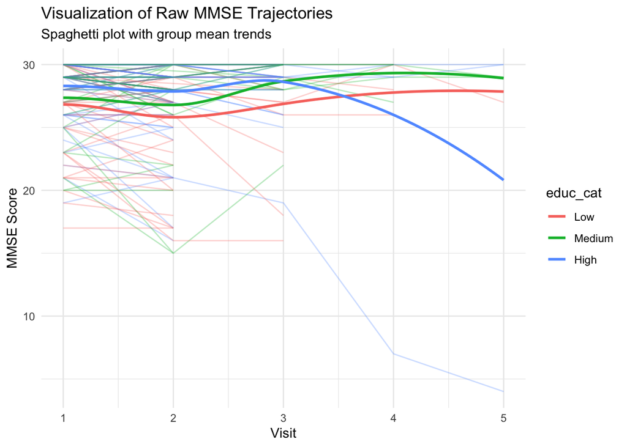

Figure 6

##### 3.2.1.2 GEE Logistic Regression Results

As discussed in Method section, we decided to use exchangable structure for GEE Analysis.

```
[1] "Estimated Working Correlation (Exchangeable Alpha): 0.6726"
```

Table 12: GEE (Exchangeable) Coefficient and Standard Error Comparison (RQ1: poor_cognition)

| term | estimate | SE_naive | SE_robust | SE_robust_bc | Z_score | P_value_BC |
| --- | --- | --- | --- | --- | --- | --- |
| (Intercept) | -0.673 | 2.060 | 2.162 | 2.226 | -0.302 | 0.762 |
| visit | 0.139 | 0.162 | 0.128 | 0.132 | 1.057 | 0.291 |
| educ_catMedium | -0.063 | 0.689 | 0.647 | 0.666 | -0.095 | 0.925 |
| educ_catHigh | -1.397 | 0.688 | 0.604 | 0.622 | -2.245 | 0.025 |
| age | -0.014 | 0.027 | 0.028 | 0.029 | -0.465 | 0.642 |
| sexM | 0.685 | 0.423 | 0.441 | 0.454 | 1.509 | 0.131 |
| visit:educ_catMedium | -0.193 | 0.254 | 0.157 | 0.161 | -1.197 | 0.231 |
| visit:educ_catHigh | -0.012 | 0.240 | 0.162 | 0.167 | -0.069 | 0.945 |

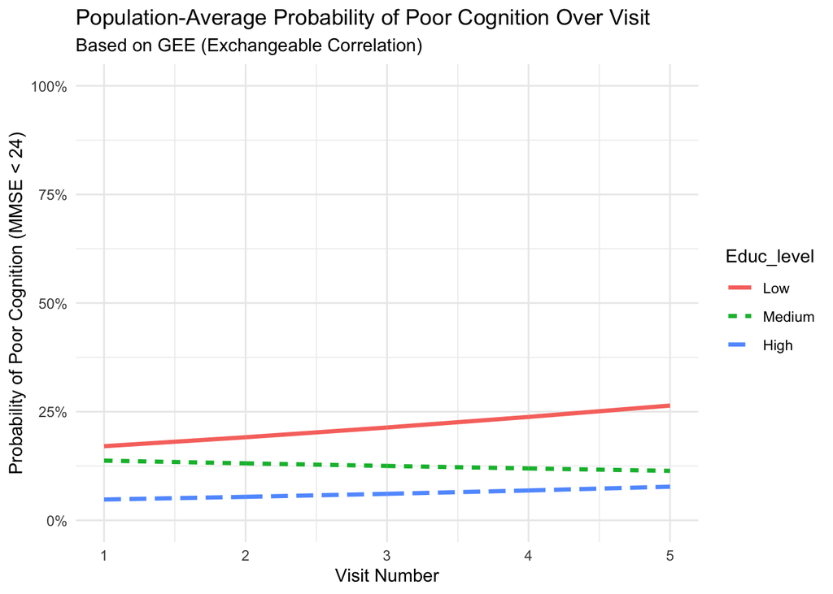

Figure 7

As for population-average predicted probabilities, Figure 7 showed that higher education corresponded to consistently lower predicted risks across all visits.

##### 3.2.1.3 Model Diagnostics

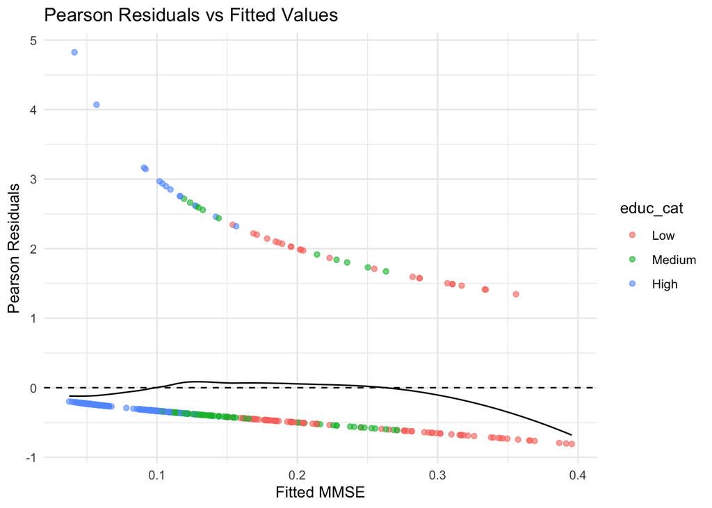

Figure 8: Pearson Residuals vs Fitted Values

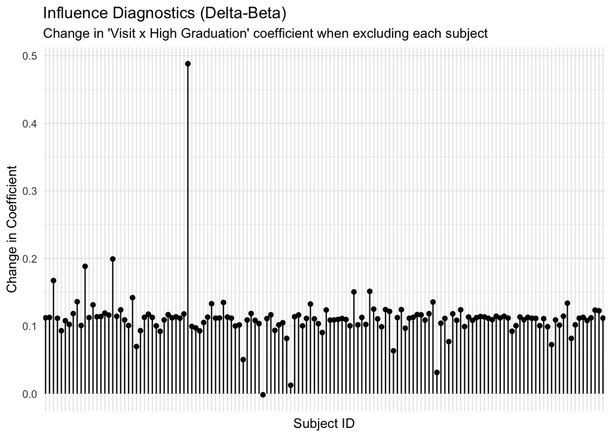

Figure 9: Influence Diagnostics (Delta-Beta)

##### 3.2.1.4 Robustness Check

Table 13: RQ1 : Robustness of MMSE Coefficient Estimates across Working Correlation Structures

| term | Independence | Exchangeable | AR1 |
| --- | --- | --- | --- |
| (Intercept) | 0.977 | -0.673 | -10.507 |
| visit | -0.202 | 0.139 | -1.801 |
| educ_catMedium | -0.068 | -0.063 | -0.192 |
| educ_catHigh | -2.277 | -1.397 | 2.084 |
| age | -0.029 | -0.014 | 0.517 |
| visit:educ_catMedium | -0.212 | -0.193 | 0.841 |
| visit:educ_catHigh | 0.513 | -0.012 | 0.257 |

#### 3.2.2 Reseach Question 2 (Continuous Outcome): Cognitive Decline

##### 3.2.2.1 Model Summary

Table 14: GEE results for RQ2

| term | estimate | std.error | statistic | p.value | LCL | UCL |
| --- | --- | --- | --- | --- | --- | --- |
| (Intercept) | 23.125 | 5.079 | 20.732 | 0.000 | 13.170 | 33.079 |
| visit | -0.764 | 0.239 | 10.224 | 0.001 | -1.232 | -0.296 |
| educ_catMedium | -0.296 | 0.784 | 0.142 | 0.706 | -1.833 | 1.242 |
| educ_catHigh | 1.711 | 0.825 | 4.302 | 0.038 | 0.094 | 3.327 |
| age | 0.063 | 0.068 | 0.860 | 0.354 | -0.070 | 0.197 |
| sexM | -1.094 | 0.552 | 3.932 | 0.047 | -2.175 | -0.013 |
| visit:educ_catMedium | 0.683 | 0.252 | 7.367 | 0.007 | 0.190 | 1.177 |
| visit:educ_catHigh | 0.100 | 0.454 | 0.049 | 0.825 | -0.789 | 0.990 |

Putting these pieces together, the model suggests that higher education, especially high education, is associated with better baseline cognitive performance as measured by MMSE, and males start slightly lower than the reference sex. Over time, both low- and high-education groups show comparable declines in MMSE, whereas the medium-education group appears relatively stable, though their baseline level is not significantly different from the low-education group. Age does not show a clear independent effect on MMSE in this adjusted model.

##### 3.2.2.2 Predicted MMSE Trajectories

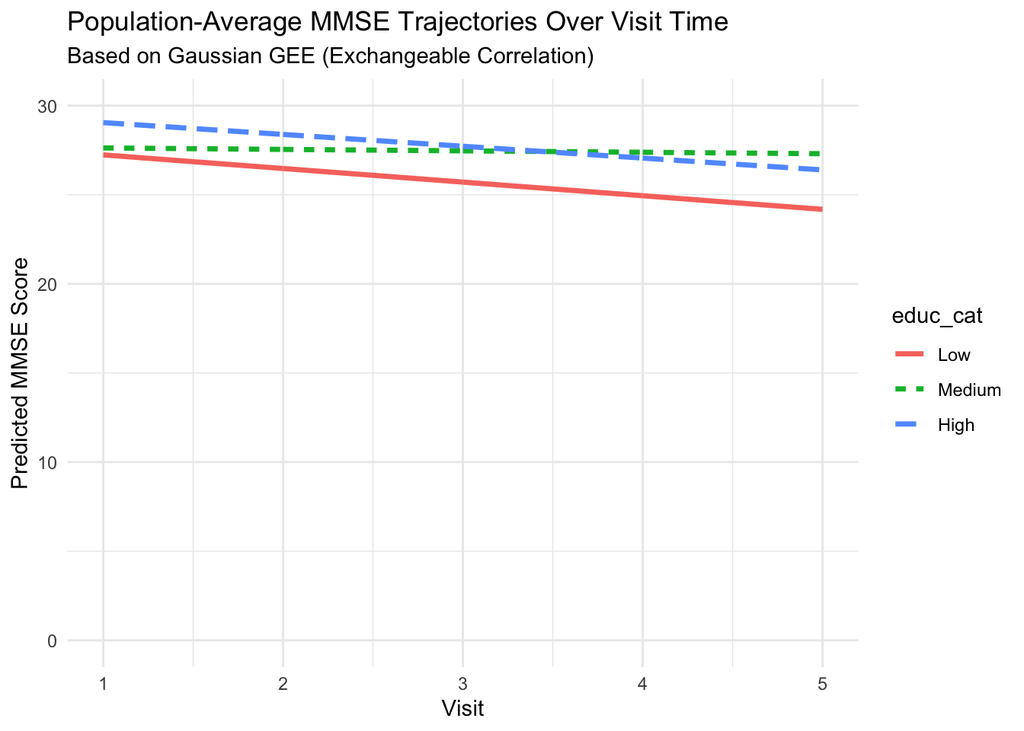

Figure 10: Population-Average MMSE Trajectories Over Visit Time

##### 3.2.2.3 Model Diagnostics

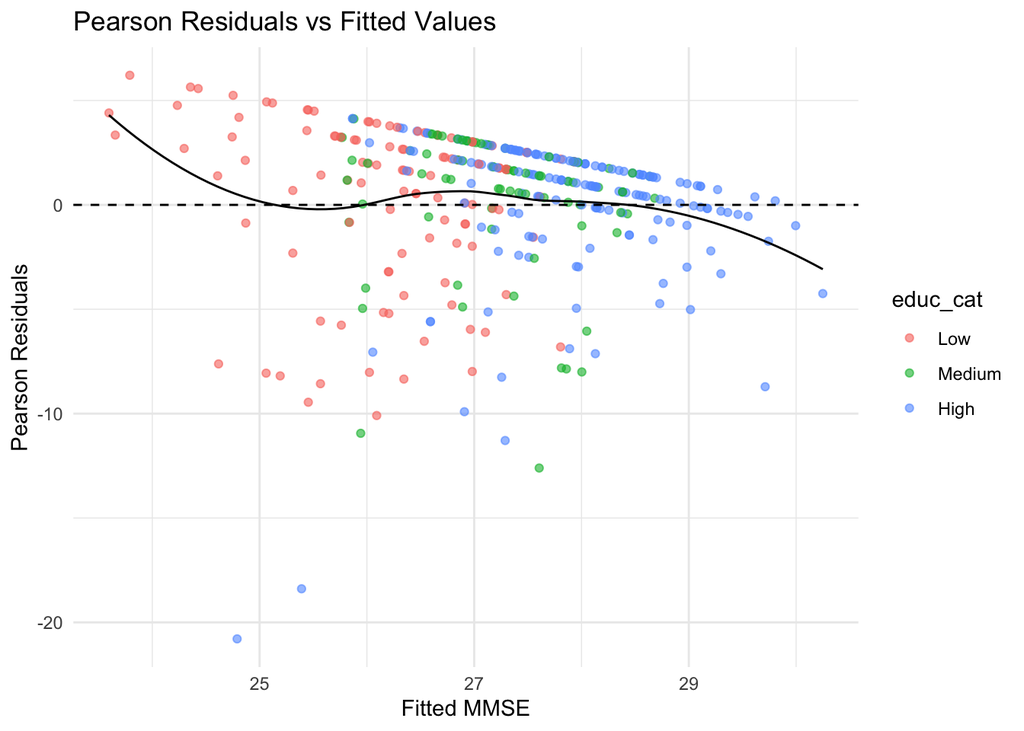

Figure 11: Pearson Residuals vs Fitted Values

Figure 11 shows that Pearson residuals are generally centered around zero across the range of fitted MMSE values, indicating that the Gaussian GEE captures the main mean structure reasonably well. Some heteroscedasticity is visible, with greater residual spread at lower fitted MMSE values, which is expected given the MMSE’s ceiling effect. The slight curvature in the LOESS line suggests minor deviation from linearity but no major systematic bias. Residual patterns are similar across education groups, indicating that model fit does not depend heavily on educational category. Overall, the residual plot supports that the chosen GEE model is adequate for population-level interpretation.

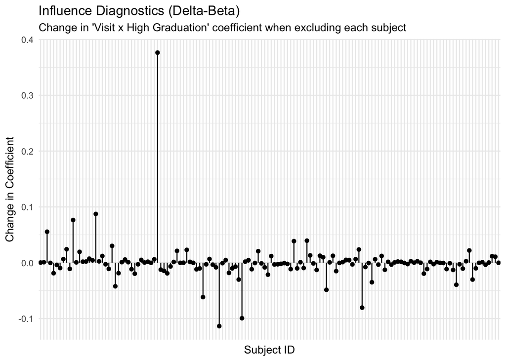

Figure 12: Influence Diagnostics (Delta-Beta)

##### 3.2.2.4 Robustness Check

Table 15: RQ2 : Robustness of MMSE Coefficient Estimates across Working Correlation Structures

[output not shown]

Table 15 shows that the key education effects are robust across working correlation structures. For all three structures, the coefficient for High education remains positive and sizable, and the Visit × Medium education interaction is consistently positive, indicating slower decline in the medium-education group. Although the sign and magnitude of the visit and Visit × High education terms vary somewhat across structures, the main qualitative conclusion—that higher education is associated with better cognitive level and that medium education is linked to slower MMSE decline—does not depend on the chosen correlation structure.

#### 3.2.3 Conclusion for GEE

Overall, the GEE models demonstrate that educational attainment meaningfully shapes cognitive trajectories in aging populations.

### 3.3 GLMM

#### 3.3.1 RQ1 Results: Probability of Poor Cognition (Logistic GLMM)

##### 3.3.1.1 Model Summary

Table 16: Results from GLMM for poor cognition (logit link) with random intercept for subject.

| term | estimate | std.error | OR | LCL | UCL | p.value |
| --- | --- | --- | --- | --- | --- | --- |
| (Intercept) | -11.187 | 2.640 | 0.000 | 0.000 | 0.002 | 0.000 |
| visit | 0.918 | 0.771 | 2.505 | 0.553 | 11.352 | 0.234 |
| educ_catMedium | 1.936 | 3.580 | 6.931 | 0.006 | 7733.810 | 0.589 |
| educ_catHigh | -2.041 | 3.926 | 0.130 | 0.000 | 285.628 | 0.603 |
| age_scaled | -0.083 | 0.828 | 0.920 | 0.182 | 4.660 | 0.920 |
| sex_baselineM | 0.480 | 1.685 | 1.615 | 0.059 | 43.940 | 0.776 |
| visit:educ_catMedium | -1.204 | 1.547 | 0.300 | 0.014 | 6.217 | 0.436 |
| visit:educ_catHigh | 0.146 | 1.283 | 1.157 | 0.094 | 14.307 | 0.910 |

```
RQ1 ICC: 0.986
```

Table 16 summarizes the fixed effects from the logistic GLMM.

##### 3.3.1.2 Model Diagnostics

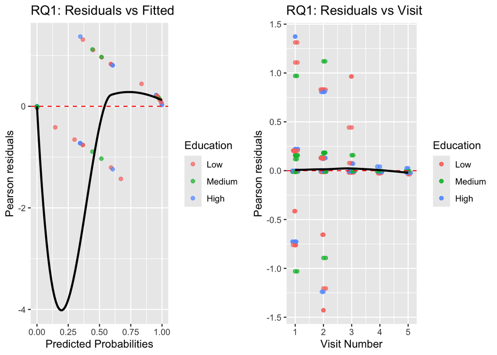

Figure 13: Residuals Diagnostics Plot

As shown in Figure 13, the left plot (Residuals vs. Fitted) displays two distinct curved lines. This is a known artifact in logistic regression diagnostics caused by the binary nature of the outcome (0 or 1). The distinct curve suggests the model is effectively separating the data, but the lack of scatter around these lines indicates limited variability in predicted probabilities.

The right plot (Residuals vs. Time) of Pearson residuals against Visit number shows that the residuals are centered around zero across all time points. The smoothed trend line remains flat and close to the zero reference line, indicating that the linearity assumption for the time effect is satisfied and there are no substantial unmodeled non-linear trends.

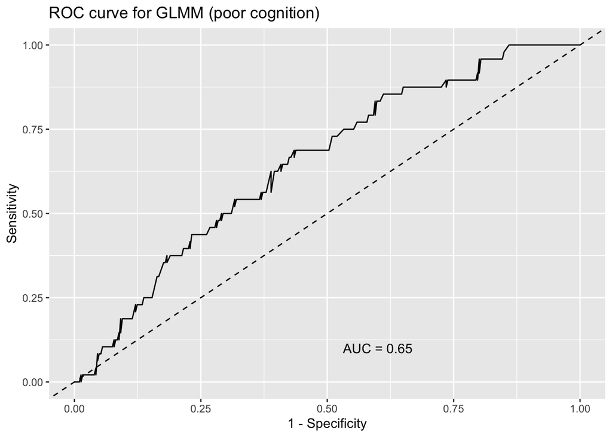

Figure 14: ROC Plot

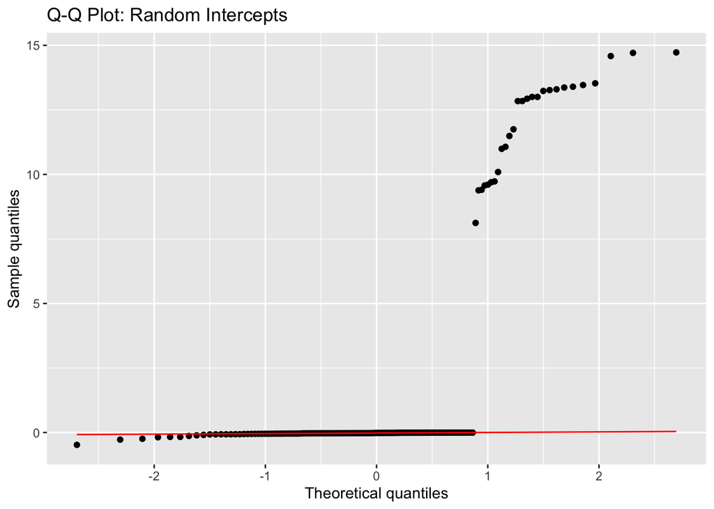

Figure 15: Q-Q plot

In Figure 15, the Q-Q plot shows a distinct “step” pattern with a gap in the middle. This confirms the issue of **complete or quasi-complete separation**. The model has essentially clustered subjects into two distinct groups: those who never experienced poor cognition (the vast majority) and those who did. This clustering explains the inflated standard errors and high ICC; the random intercept effectively predicts the outcome perfectly for most subjects, leaving little variance for the fixed effects to explain.

#### 3.3.2 Reseach Question 2 (Continuous Outcome): Cognitive Decline

A Linear Mixed Model was fit to examine the trajectories of MMSE scores over time.

##### 3.3.2.1 Model Summary

Table 17: Fixed-effect estimates from the linear mixed model for MMSE (RQ2).

| term | estimate | conf.low | conf.high | p.value |
| --- | --- | --- | --- | --- |
| (Intercept) | 27.093 | 21.486 | 32.700 | 0.000 |
| visit | -0.577 | -1.007 | -0.147 | 0.009 |
| educ_catMedium | -0.270 | -2.165 | 1.626 | 0.780 |
| educ_catHigh | 1.729 | 0.151 | 3.308 | 0.032 |
| age_baseline | 0.009 | -0.063 | 0.080 | 0.812 |
| sex_baselineM | -1.138 | -2.257 | -0.019 | 0.046 |
| visit:educ_catMedium | 0.647 | 0.023 | 1.271 | 0.042 |
| visit:educ_catHigh | 0.040 | -0.506 | 0.585 | 0.887 |

```
RQ2 ICC (Baseline correlation): 0.756
```

##### 3.3.2.2 Model Diagnostics

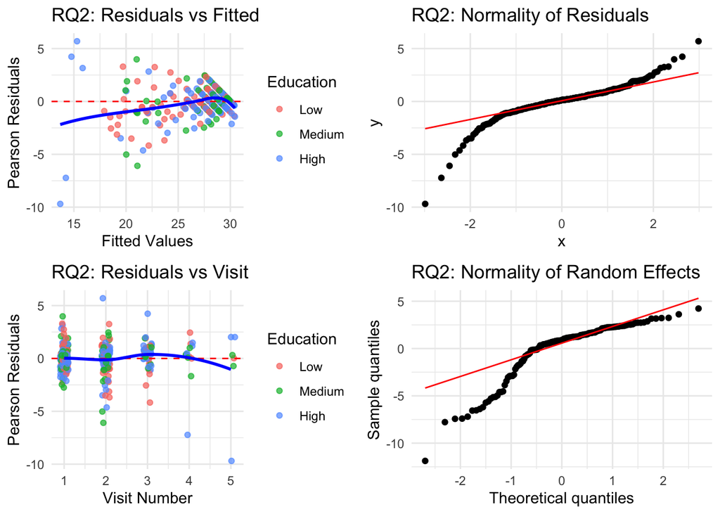

Figure 16: Residuals Diagnostics Plot

The Residuals vs. Fitted plot ( Figure 16 upperleft) shows clear heteroscedasticity: residuals vary widely at lower fitted values but become compressed as fitted values approach the upper range of MMSE scores. This inverse-funnel pattern is consistent with the ceiling effect of the MMSE, where individuals with high predicted cognition (often those with higher education) cannot score above 30, reducing the observable variability. Also, a variance‐stabilizing transformation (e.g., square root or ordinal modeling) could theoretically help, but is usually not applied to MMSE due to interpretability concerns. Although this violates the strict homoscedasticity assumption, such patterns are common in cognitive aging research and do not typically bias fixed-effect estimates in linear mixed models. The loess smoothing line remains close to zero with only mild curvature, suggesting that the linearity assumption is reasonably met.

The Residuals vs. Visit plot(Figure 16 bottomleft) shows that residuals are centered around zero across all visit numbers, and the loess curve is essentially flat. This indicates no systematic over- or under-prediction at any point in time, supporting the appropriateness of modeling Visit as a linear predictor. There is no evidence that a nonlinear or higher-order time term is required.

The Q–Q plot for residuals(Figure 16 upperright) shows moderate deviation in the lower tail, indicating heavy left-tail behavior. This reflects the well-known distributional characteristics of MMSE scores, where the lowest-scoring individuals produce disproportionately large negative residuals. Despite this, given the sample size and the robustness of linear mixed models, **fixed-effect estimates remain reliable**. Mild deviations from normality in residuals are unlikely to meaningfully distort inference.

The **Normality of Random Effects** (Figure 16 bottomright) shows that the points follow the line reasonably well in the center but deviate at the tails (S-shape). The assumption of normally distributed random effects is roughly met, though there is some heavy-tailed behavior.

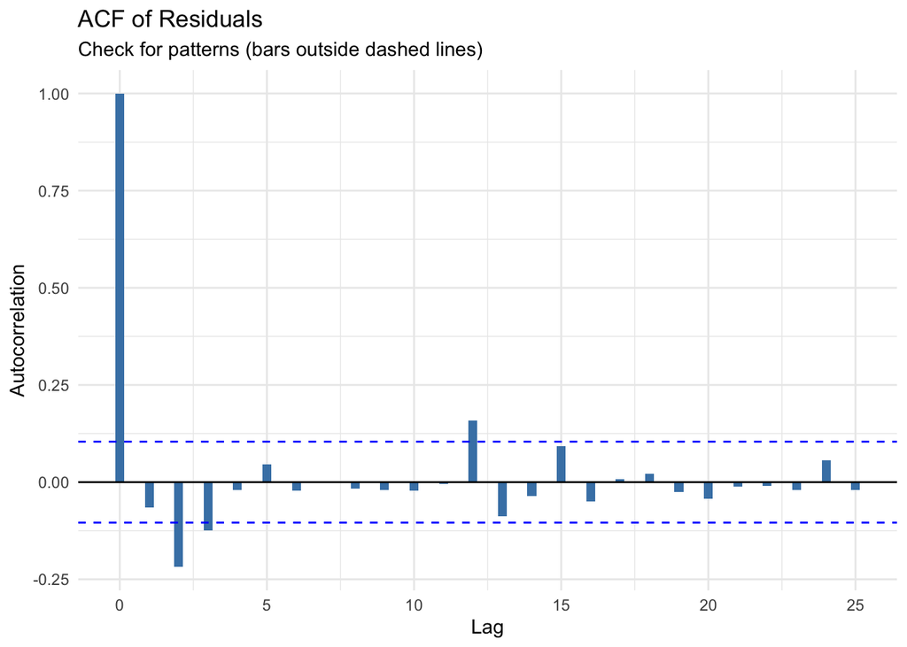

Figure 17: Autocorrelation Function (ACF) Plot

The Autocorrelation Function (ACF) plot (Figure 17) checks if there is any remaining correlation between visits that the model failed to capture. The bars for nearly all lags fall within the blue dashed confidence bounds (representing zero correlation). This confirms that, generally, including the random intercept and random slope successfully accounted for the within-subject longitudinal correlation, leaving the residuals temporally independent.

## 4 Discussion

Across the GLM, GEE, and GLMM frameworks, our findings collectively characterize how demographic factors and diagnostic group membership relate to cognitive status and cognitive decline in the OASIS-2 cohort. Although each model addresses a distinct research question and operates under different assumptions, the results converge to provide a coherent picture of baseline cognitive differences and longitudinal trajectories.

### 4.2 Research Question 2: Predictors of Cognitive Decline (Continuous Outcome)

Shifting to the continuous MMSE outcome allowed us to avoid the separation issue while leveraging the full variability of the data.

### 4.3 Model Preference

Another important concern is the decision to dichotomize MMSE at a cutoff of 24 to define “poor cognition.” While clinically intuitive, binarizing a continuous measure discards information about within-range variability and can exacerbate instability, especially when the impaired category is rare. This was evident in the logistic GLMM, where quasi-complete separation and extreme ICC values suggested that the binary outcome was largely driven by a small subset of impaired observations, leading to wide confidence intervals and imprecise odds ratios. In contrast, modeling MMSE as a continuous outcome in the linear mixed model made fuller use of the data and yielded more stable estimates of time trends and education effects, even though ceiling effects and mild deviations from normality remained. Future work could prioritize continuous or ordinal modeling of cognitive scores, reserving dichotomization for secondary, clinically focused analyses, in order to improve efficiency, reduce separation problems, and better characterize subtle trajectories of cognitive change.

Among all analytic frameworks considered, the continuous-outcome GEE and LMM models therefore provide the most reliable, interpretable, and statistically stable results. They avoid the separation problems inherent in the binary outcome, better exploit within-subject longitudinal information, and yield estimates that align with clinical expectations about gradual cognitive decline and the protective role of education. For these reasons, our primary substantive interpretations focus on the continuous GEE and LMM findings, whereas binary models are treated as secondary, complementary analyses aimed at illustrating clinically relevant impairment thresholds rather than driving inference.

### 4.4 Limitations

For GEE, several limitations should be acknowledged when interpreting these findings. First, the data may be subject to **informative dropout**, as participants with faster cognitive decline may be more likely to discontinue follow-up, potentially biasing longitudinal estimates even under GEE’s population-average framework. Second, the MMSE measure exhibits a well-known **ceiling effect**, particularly among highly educated or cognitively intact individuals, which can compress variability at the upper end and attenuate detectable differences in decline patterns. Third, **education was categorized into three broad groups**, which simplifies interpretation but may obscure more nuanced dose–response relationships or within-group heterogeneity. Additionally, the models assume correctly specified mean structure and rely on robust standard errors to mitigate correlation misspecification, but minor deviations observed in residual diagnostics suggest that some nonlinearity or unexplained heterogeneity may remain. Lastly, the sample size within some education–visit combinations is modest, which may limit power to detect interaction effects.

What’s more, poor cognition was relatively rare and many participants never became impaired, the logistic GLMM was vulnerable to quasi-complete separation, leading to unstable fixed-effect estimates, inflated standard errors, and an extremely high ICC; as a result, inferences from this model should be interpreted with particular caution. The GLM and GLMM also relied on a limited set of baseline covariates and did not incorporate potentially important time-varying factors (e.g., comorbidities, medications, lifestyle changes), raising the possibility of residual confounding. For the linear mixed model of MMSE trajectories, we treated time as linear and used a Gaussian error structure, choices that favor interpretability but may oversimplify nonlinear or floor/ceiling dynamics in cognitive change. Finally, all models were fit within a single cohort with modest sample sizes in some strata, which restricts generalizability and limits power to detect subtle effects or higher-order interactions, particularly when outcomes are skewed or clustered at the extremes.

## 6 Data Availability

OASIS-2 data could be downloaded through kaggle (see ‘/Link.txt’ for more information). For convenience, we also upload the data we used in github repo (see ‘/data/oasis_longitudinal.csv’)

## 7 Code Avaiability

All codes are available at ‘/code’. The code for `.Qmd` reproduction is also provided. Hope you all would enjoy our project!

## 8 Reference

[1]

Alzheimer’s Disease International, “World alzheimer report 2020: Design, dignity, dementia.” Sep. 21, 2020. Available: https://www.alzint.org/resource/world-alzheimer-report-2020/

[2]

World Health Organization, “Dementia: Key facts.” 2025. Available: https://www.who.int/news-room/fact-sheets/detail/dementia

[3]

Alzheimer’s Association, “2024 alzheimer’s disease facts and figures.” 2024. Available: https://www.alz.org/getmedia/ef8f48f9-ad36-48ea-87f9-b74034635c1e/alzheimers-facts-and-figures.pdf

[4]

M. Prince, A. Wimo, M. Guerchet, G.-C. Ali, Y.-T. Wu, and M. Prina, “World alzheimer report 2025.” 2025. Available: https://www.alzint.org/resource/world-alzheimer-report-2025/

[5]

M. F. Folstein, S. E. Folstein, and P. R. McHugh, “Mini-mental state: A practical method for grading the cognitive state of patients for the clinician,” *Journal of Psychiatric Research*, vol. 12, no. 3, pp. 189–198, 1975.

[6]

T. N. Tombaugh and N. J. McIntyre, “The mini-mental state examination: A comprehensive review,” *Journal of the American Geriatrics Society*, vol. 40, no. 9, pp. 922–935, 1992.

[7]

S. T. Creavin *et al.*, “Mini-mental state examination (MMSE) for the detection of dementia in clinically unevaluated people aged 65 and over in community and primary care populations,” *Cochrane Database of Systematic Reviews*, vol. 2016, no. 1, p. CD011145, 2016, doi: 10.1002/14651858.CD011145.pub2.

[8]

S. E. O’Bryant *et al.*, “Detecting dementia with the mini-mental state examination in highly educated individuals,” *Archives of Neurology*, vol. 65, no. 7, pp. 963–967, 2008, doi: 10.1001/archneur.65.7.963.

[9]

F. Salis, D. Costaggiu, and A. Mandas, “Mini-mental state examination: Optimal cut-off levels for mild and severe cognitive impairment,” *Geriatrics*, vol. 8, no. 1, p. 12, 2023, doi: 10.3390/geriatrics8010012.

[10]

R. M. Crum, J. C. Anthony, S. S. Bassett, and M. F. Folstein, “Population-based norms for the mini-mental state examination by age and educational level,” *JAMA*, vol. 269, no. 18, pp. 2386–2391, 1993, doi: 10.1001/jama.269.18.2386.

[11]

L. B. Zahodne *et al.*, “Education does not slow cognitive decline with aging: 12-year evidence from the victoria longitudinal study,” *Journal of the International Neuropsychological Society*, vol. 17, no. 6, pp. 1039–1046, 2011, doi: 10.1017/S1355617711001044.

[12]

R. Kim and W. Chung, “Effect of aging on educational differences in the risk of cognitive impairment: A gender-specific analysis using korean longitudinal study of aging (2006–2016),” *Healthcare*, vol. 10, no. 6, p. 1062, 2022, doi: 10.3390/healthcare10061062.

[13]

S. Luo, W. Chen, W. Hu, *et al.*, “Parental education, own education, and cognitive function in middle-aged and older adults,” *JAMA Network Open*, vol. 8, no. 5, p. e2513036, 2025, doi: 10.1001/jamanetworkopen.2025.13036.